Lake Name: Chautauqua Lake

Lake acreage: 13163.9

County: CHAUTAUQUA

PWLID: 0202-0020, 0202-0072

Waterbody Classification: A

Coordinates: 42.219885,-79.455423

Is this waterbody a public water supply: Yes

Are there DOH desingated beaches on this waterbody: Yes

Open Water Indicators

2018 Sampling Results

Seasonal Change

06-17

07-01

07-14

07-15

07-29

08-08

08-19

09-03

09-30

Clarity (m)

2.60

1.90

1.30

2.60

1.32

0.98

1.05

0.88

1.10

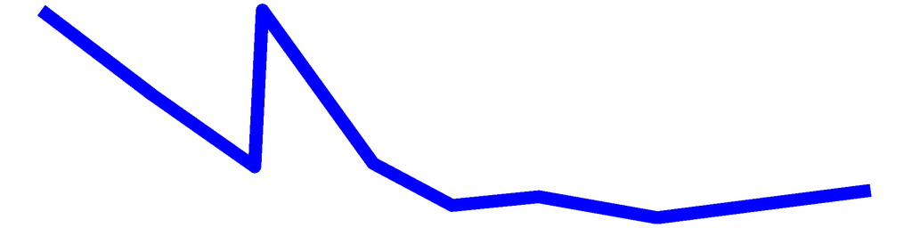

Surface TP (mg/L)

0.02

0.03

0.03

0.02

0.04

0.04

0.04

0.05

0.06

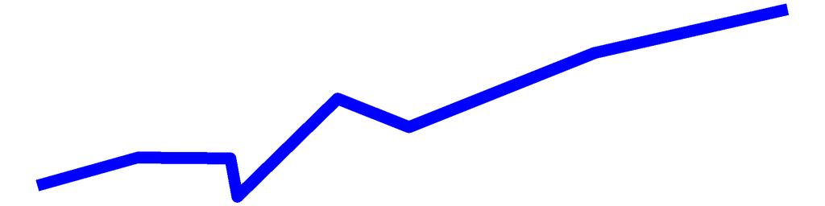

Surface TDP (mg/L)

0.02

0.01

0.02

0.02

0.01

0.02

0.02

0.02

0.03

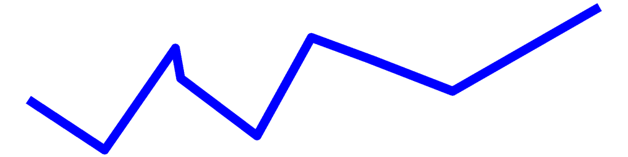

Deep TP (mg/L)

0.02

0.04

0.05

0.03

0.06

0.05

0.05

0.04

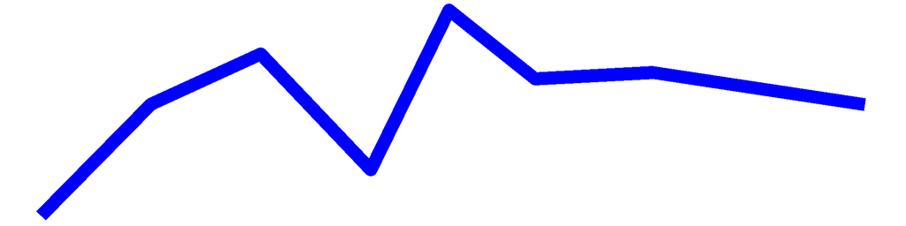

Deep TDP (mg/L)

0.01

0.05

0.04

0.01

0.05

0.03

0.03

0.04

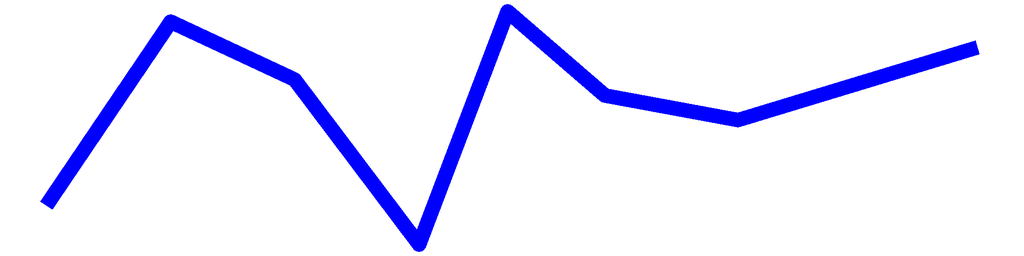

TN (mg/L)

0.48

0.57

0.66

0.48

0.67

0.62

0.64

0.68

0.45

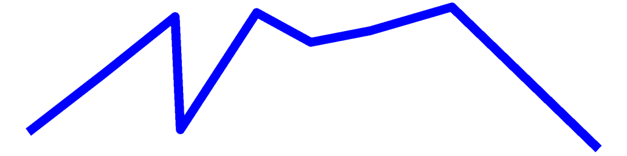

TDN (mg/L)

0.45

0.51

0.54

0.52

0.57

0.56

0.49

0.69

0.43

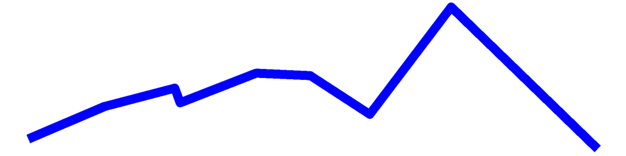

TN:TP

20.46

19.12

22.19

23.19

15.25

16.76

14.41

12.44

7.05

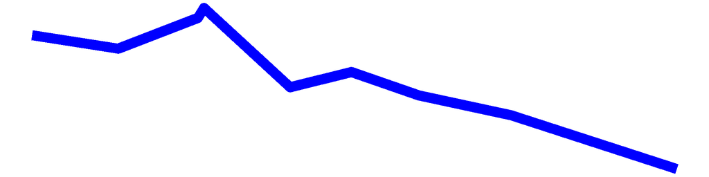

Surface NH3 (mg/L)

0.12

0.05

0.04

0.03

0.18

0.01

0.06

0.15

0.05

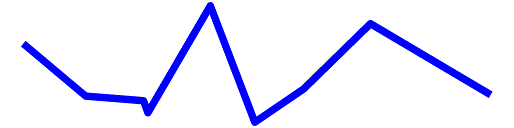

Deep NH3 (mg/L)

0.03

0.12

0.12

0.06

0.03

0.12

0.18

0.02

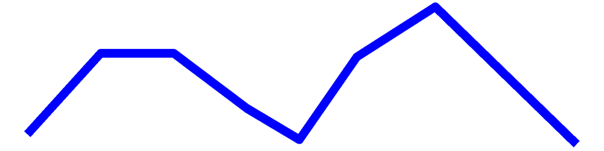

Chl.a (ug/L)

7.80

13.50

9.20

10.10

25.95

22.10

35.00

47.75

16.65

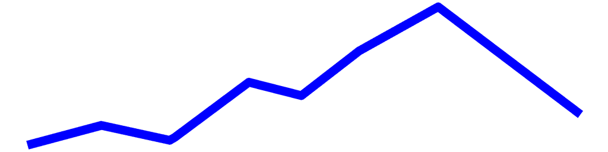

pH

7.88

8.00

8.06

8.07

8.14

8.37

8.66

7.88

7.38

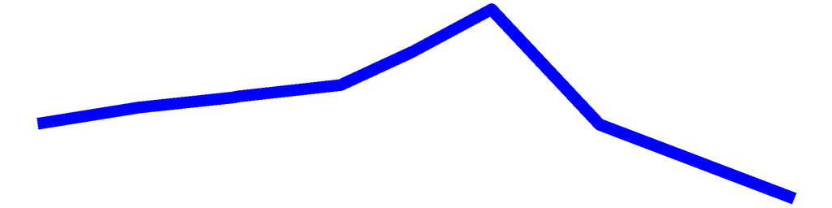

Cond (umho/cm)

216.80

228.20

148.50

237.70

205.00

231.60

213.20

193.90

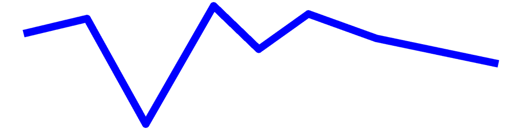

Surface Calcium (mg/L)

Bottom Calcium (mg/L)

Surface Chloride (mg/L)

14.20

24.00

25.70

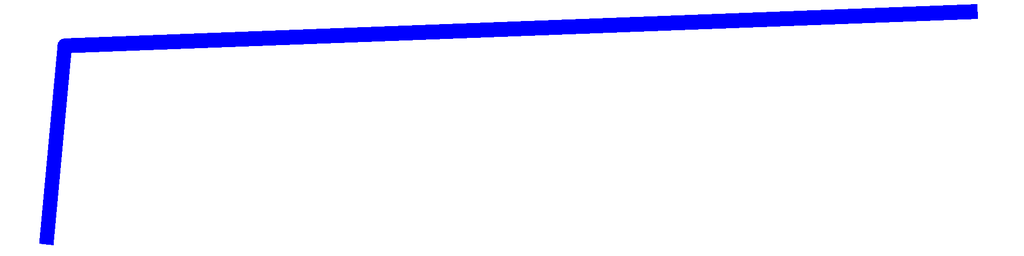

Bottom Chloride (mg/L)

Upper Temp (degC)

25.00

27.00

29.00

26.00

25.00

26.25

25.75

25.50

18.75

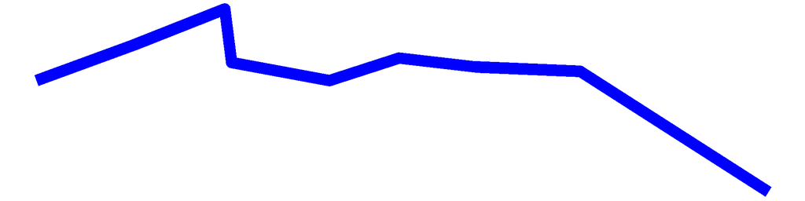

Deep Temp (degC)

20.00

20.00

19.00

24.00

23.00

23.00

23.00

19.00

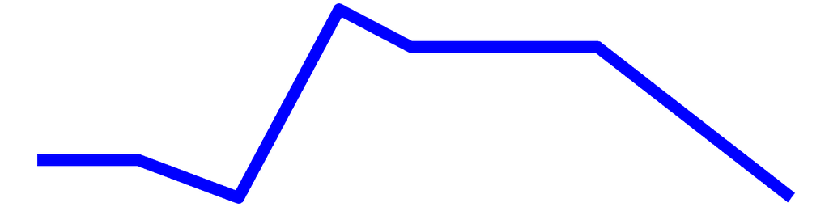

FP BG Chl.a (ug/L)

10.73

20.18

16.51

11.23

36.87

33.54

45.60

59.76

16.63

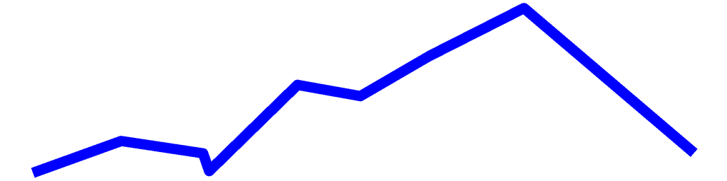

## Chautauqua Lake – Sampling Season Results

### HABs Status

#### Open Water Algae

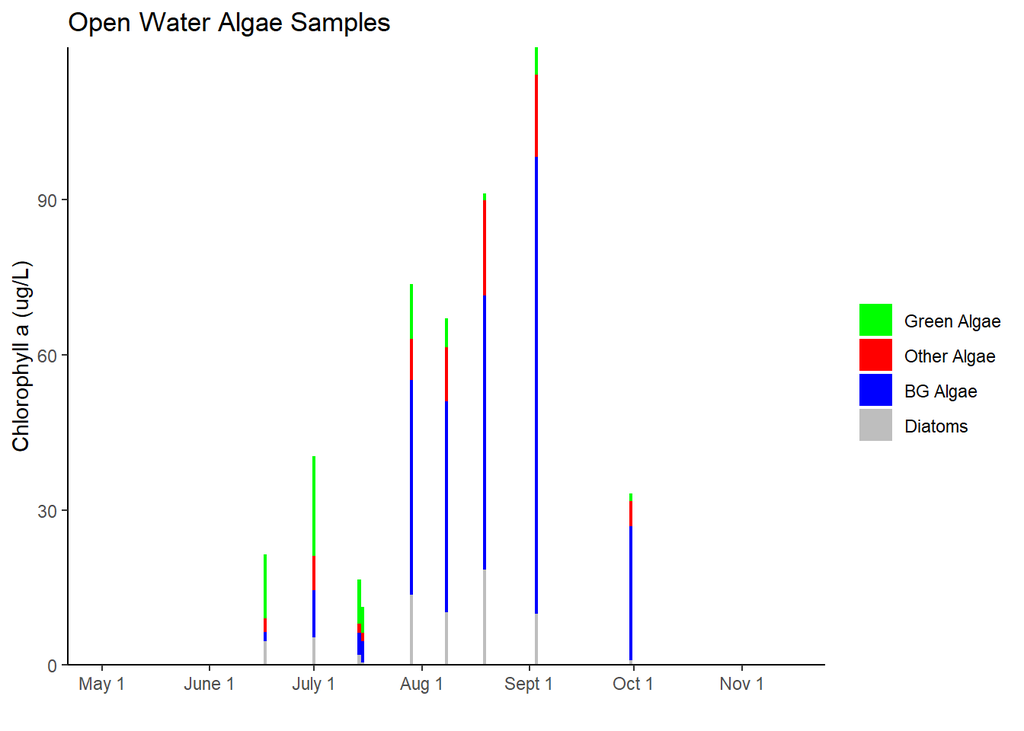

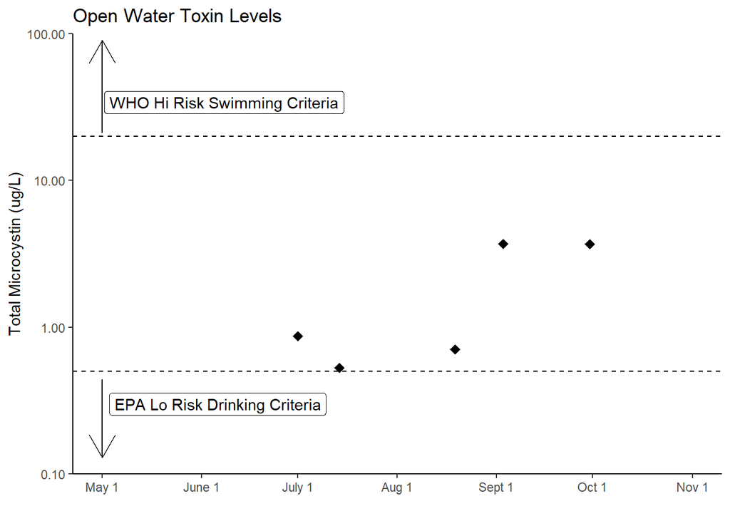

#### Shoreline Algae

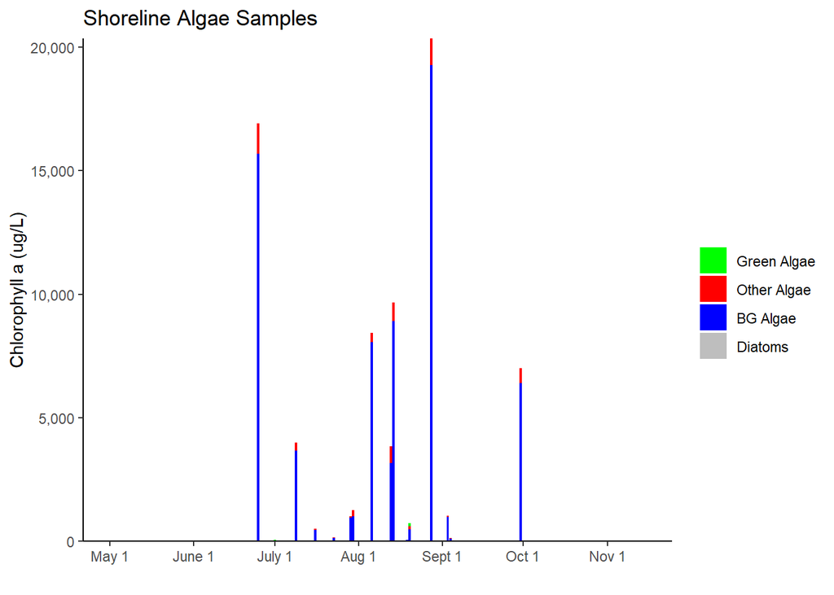

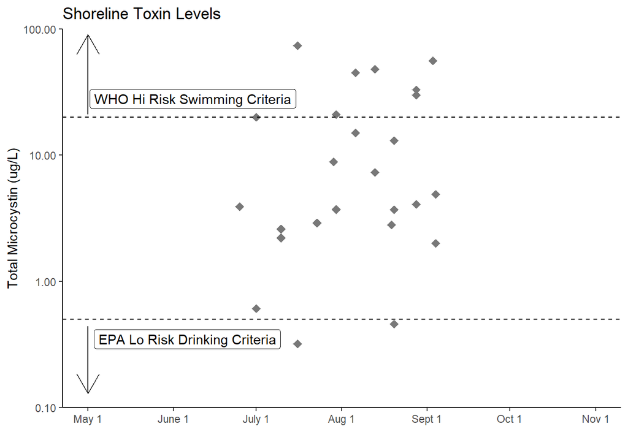

## Chautauqua Lake Long-Term Trend Analysis

#### Clarity

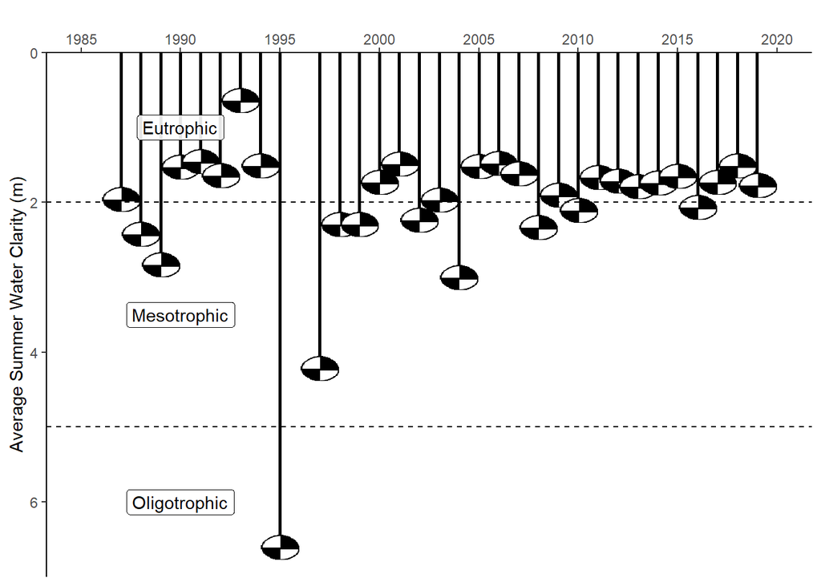

#### Chlorophyll *a*

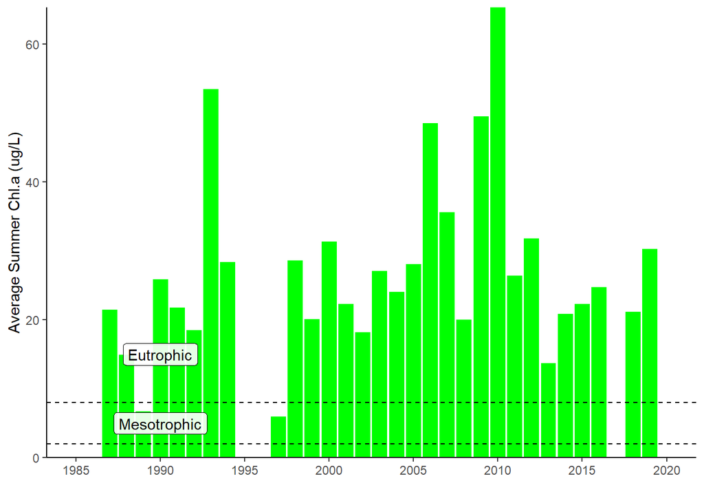

#### Surface and Deep Phosphorus

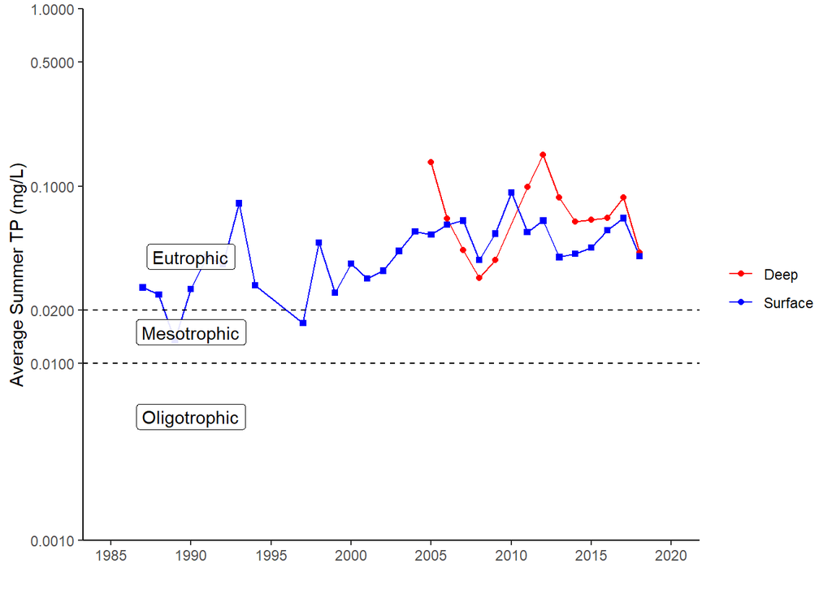

#### Nitrogen

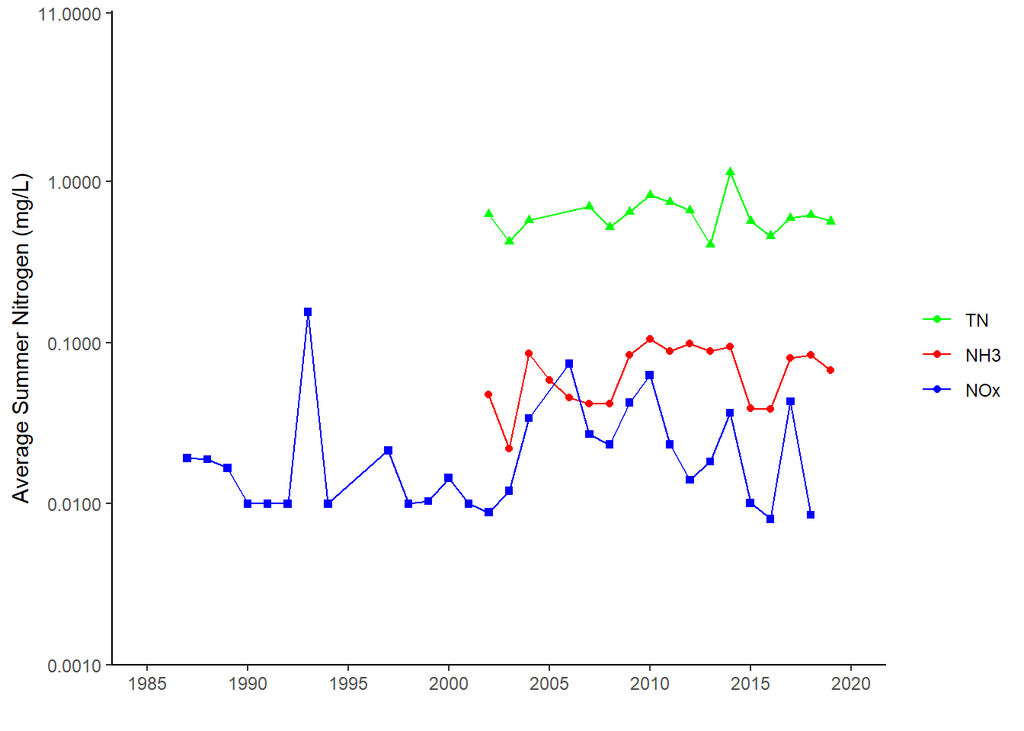

#### TN : TP

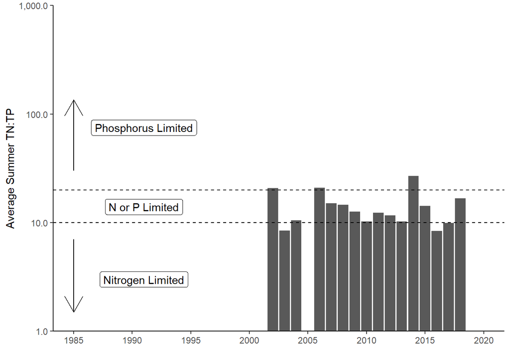

#### pH

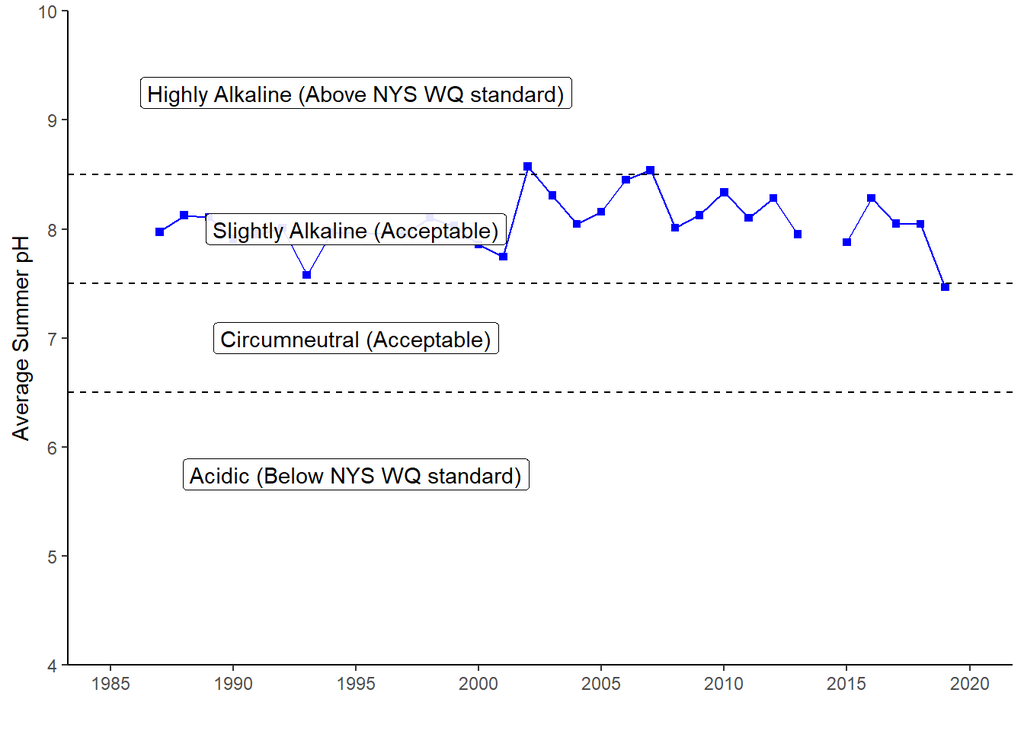

#### Specific Conductance

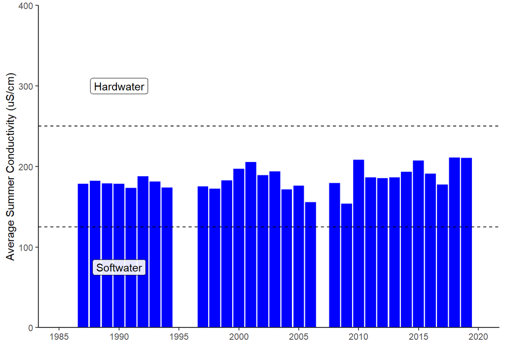

#### Calcium

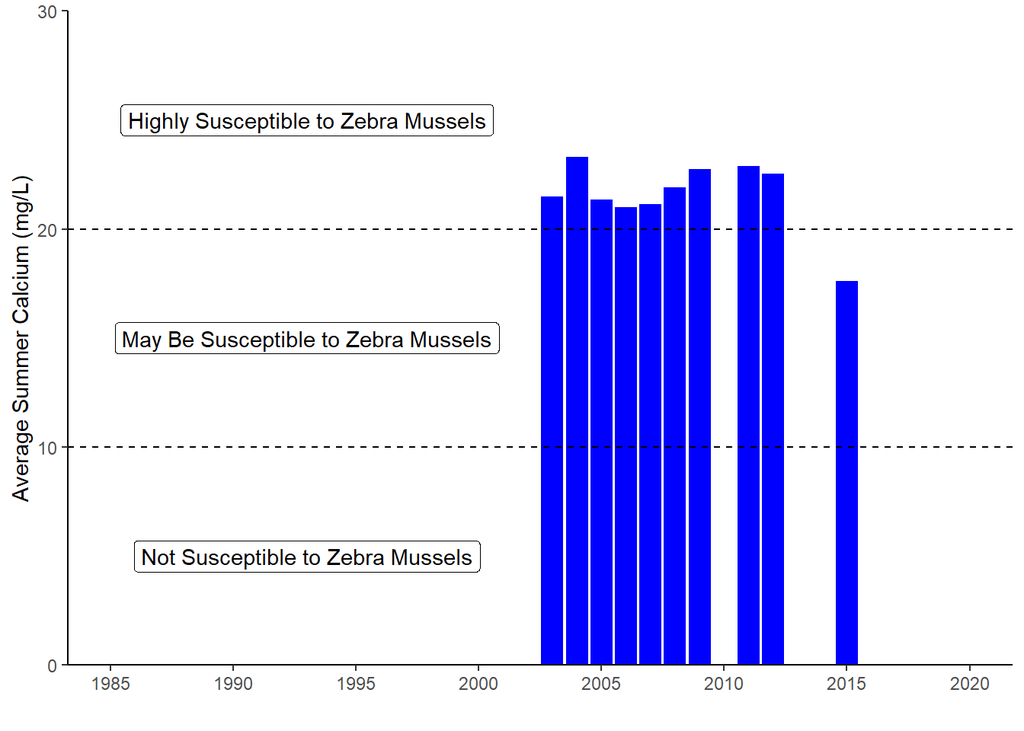

#### Chloride

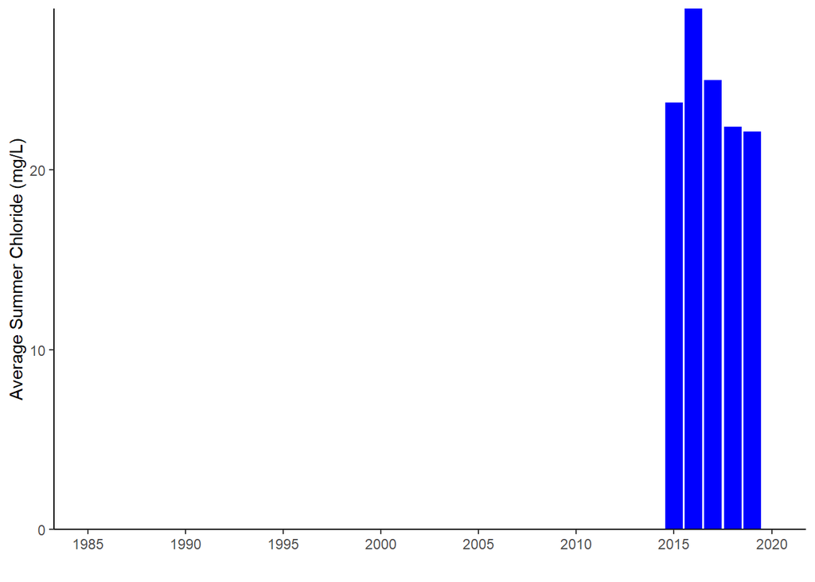

#### Color

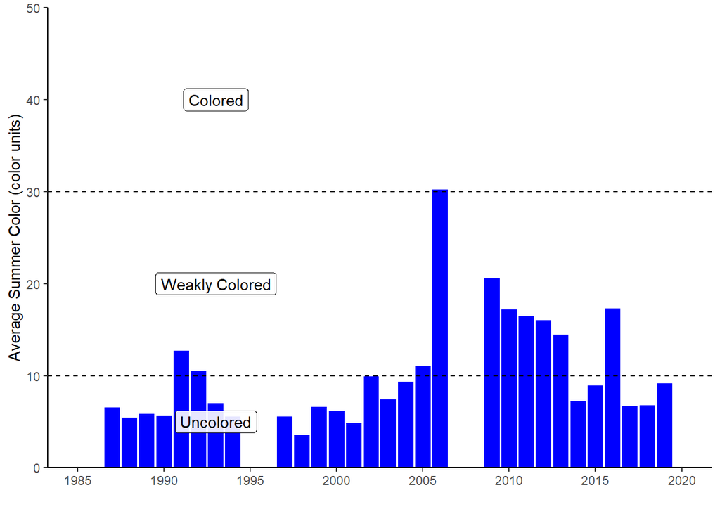